# Exploratory data analysis of the National Collision Database

## Summary of the data set

The data we are using is from the National Collision Database and can be found on the Government of Canada website. It’s a database that contains all police-reported motor vehicle collisions on public roads in Canada. The data we specifically chose was from 2017. Each row provides several data points for a passenger with the detailed summary statistics of the collision.

## Exploratory Analysis Of Training Set

We made several plots to identify which features were important to predicting fatal and non-fatal car accidents.

### Hour of the Day and Fatal Crashes

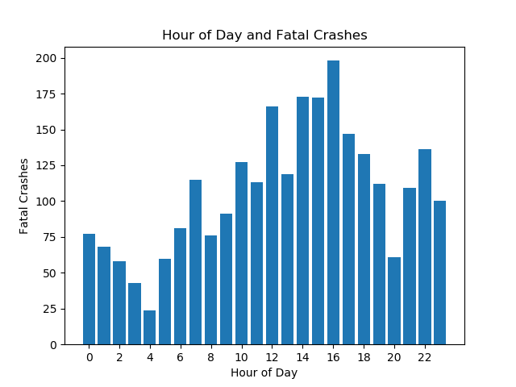

As can be shown in the graph above, most of fatal accidents occur between 14:00 to 16:00 indicating that are likely more cars on the road as people are coming back home from work. It is also understandable that few accidents occur at non-busy times such as 2:00am to 4:00am.

### Hour of the Day and Non-Fatal Crashes

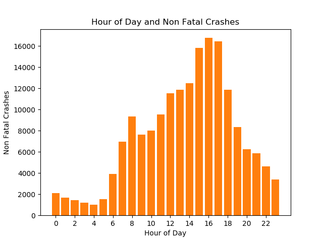

### Features With Highest Fatal Crashes

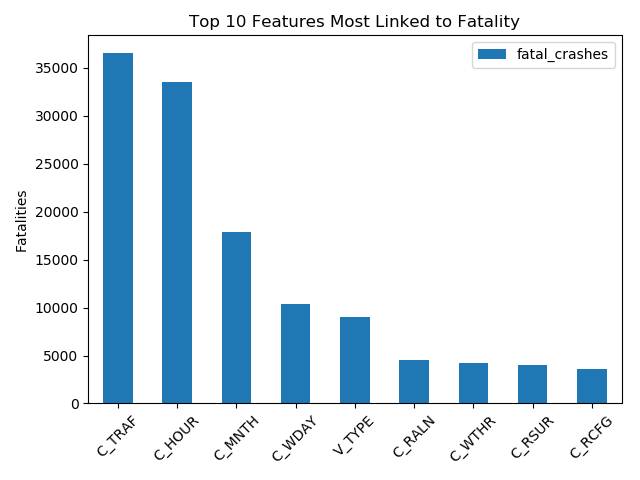

The most important feature according to EDA for fatal collisions was `C_TRAF_18` which is a variable indicating whether there was a traffic control present. Thereby, locations with no traffic control experienced higher fatal car collisions. Furthermore, we found it surprising that the `C_WTHR_1` was an important feature indicating sunny and clear weather. We would have expected higher collisions to take place during less ideal weather. Lastly, we also found that normal and dry roads as named `C_RSUR_1` was another critical feature for fatal-crashes.

### Features With Highest Non-Fatal Crashes

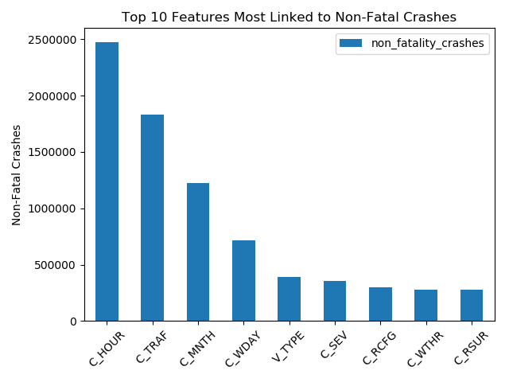